# Session_4-AnalysingData

## 3.3 GLM

Let’s run a first GLM (Generalised Linear Model). A GLM uses a special family “binomial” as it assumes the outcome has a binomial distribution. In general, results from a Logistic Regression are close to what we get from SDT (see above).

To run the results, we will change the reference level for both response and grammaticality. The basic assumption about GLM is that we start with our reference level being the “no” responses to the “ungrammatical” category. Any changes to this reference will be seen in the coefficients as “yes” responses to the “grammatical” category.

### 3.3.1 Model estimation and results

The results below show the logodds for our model.

```r
levels(grammatical$response)
```

```
[1] "yes" "no"
```

```r
levels(grammatical$grammaticality)
```

```
[1] "grammatical"   "ungrammatical"
```

```r
grammatical$response <- relevel(grammatical$response, ref = "no")
grammatical$grammaticality <- relevel(grammatical$grammaticality, ref = "ungrammatical")

mdl.glm <- glm(response ~ grammaticality, data = grammatical, family = binomial)
summary(mdl.glm)
```

```
Call:
glm(formula = response ~ grammaticality, family = binomial, data = grammatical)

Deviance Residuals:
    Min       1Q   Median       3Q      Max
-2.4676  -0.6039   0.3124   0.3124   1.8930

Coefficients:
                          Estimate Std. Error z value Pr(>|z|)
(Intercept)                -1.6094     0.3464  -4.646 3.38e-06 ***
grammaticalitygrammatical   4.6052     0.5744   8.017 1.08e-15 ***
---
Signif. codes:  0 ‘***’ 0.001 ‘**’ 0.01 ‘*’ 0.05 ‘.’ 0.1 ‘ ’ 1

(Dispersion parameter for binomial family taken to be 1)

    Null deviance: 210.050  on 164  degrees of freedom
Residual deviance:  94.271  on 163  degrees of freedom
AIC: 98.271

Number of Fisher Scoring iterations: 5
```

```r
tidy(mdl.glm) %>%
  select(term, estimate) %>%
  mutate(estimate = round(estimate, 3))
```

| term | estimate |
| --- | --- |
| (Intercept) | -1.609 |
| grammaticalitygrammatical | 4.605 |

```r
# to only get the coefficients
mycoef2 <- tidy(mdl.glm) %>% pull(estimate)
```

The results show that for one unit increase in the response (i.e., from no to yes), the logodds of being “grammatical” is increased by 4.6051702 (the intercept shows that when the response is “no”, the logodds are -1.6094379). The actual logodds for the response “yes” to grammatical is 2.9957323

### 3.3.2 Getting “true” coefficients from GLM

How to get the true coefficients? How to suppress the Intercept?

Here we will run the same GLM model above but by suppressing the “Intercept”. The idea here is to get the “true” coefficient for a “grammatical” and a “yes” response. We can use the above code, i.e., “mycoef2[1]+mycoef2[2]” or as below

```r
# An intercept is always included in any regression, but you can specify it with "1"
## glm(response~1+grammaticality,data=grammatical,family = binomial)

mdl.glm2 <- glm(response ~ 0 + grammaticality, data = grammatical, family = binomial)
summary(mdl.glm2)
```

```
Call:
glm(formula = response ~ 0 + grammaticality, family = binomial,
    data = grammatical)

Deviance Residuals:
    Min       1Q   Median       3Q      Max
-2.4676  -0.6039   0.3124   0.3124   1.8930

Coefficients:
                            Estimate Std. Error z value Pr(>|z|)
grammaticalityungrammatical  -1.6094     0.3464  -4.646 3.38e-06
grammaticalitygrammatical     2.9957     0.4582   6.538 6.25e-11

grammaticalityungrammatical ***
grammaticalitygrammatical   ***
---
Signif. codes:  0 ‘***’ 0.001 ‘**’ 0.01 ‘*’ 0.05 ‘.’ 0.1 ‘ ’ 1

(Dispersion parameter for binomial family taken to be 1)

    Null deviance: 228.739  on 165  degrees of freedom
Residual deviance:  94.271  on 163  degrees of freedom
AIC: 98.271

Number of Fisher Scoring iterations: 5
```

### 3.3.3 Logodds to Odd ratios

Logodds can be modified to talk about the odds of an event. For our model above, the odds of “grammatical” receiving a “yes” response increase by 100; whereas receiving a “no” is a mere 0.2. Using the second model (i.e., without an Intercept) allows us to get the odd ratios for each of responses to “Ungrammatical” and “Grammatical”, which is still 0.2 for “ungrammatical” and 20 for “grammatical”, i.e., 20 times more

```r
exp(coef(mdl.glm))
```

```
              (Intercept) grammaticalitygrammatical
                      0.2                     100.0
```

```r
exp(coef(mdl.glm2))
```

```
grammaticalityungrammatical   grammaticalitygrammatical
                        0.2                        20.0
```

### 3.3.4 LogOdds to proportions

If you want to talk about the percentage “accuracy” of our model, then we can transform our loggodds into proportions. This shows that the proportion of “grammatical” receiving a “yes” response increases by 99% (or 95% based on our “true” coefficients)

```r
plogis(coef(mdl.glm))
```

```
              (Intercept) grammaticalitygrammatical
                0.1666667                 0.9900990
```

```r
plogis(coef(mdl.glm2))
```

```
grammaticalityungrammatical   grammaticalitygrammatical
                  0.1666667                   0.9523810
```

### 3.3.5 GLM as a classification tool

The code below demonstrates the links between our GLM model and what we had obtained above from SDT. The predictions’ table shows that our GLM was successful at obtaining prediction that are identical to our initial data setup. Look at the table here and the table above. Once we have created our table of outcome, we can compute percent correct, the specificity, the sensitivity, the Kappa score, etc.. this yields the actual value with the SD that is related to variations in responses.

```r
## predict(mdl.glm)>0.5 is identical to
## predict(glm(response~grammaticality,data=grammatical,family = binomial),type="response")
grammatical$response <- relevel(grammatical$response, "yes")
grammatical$grammaticality <- relevel(grammatical$grammaticality, "grammatical")
mdl.glm.C <- glm(response ~ grammaticality, data = grammatical,family = binomial)
tbl.glm <- table(grammatical$response, predict(mdl.glm.C, type = "response")>0.5)
colnames(tbl.glm) <- c("grammatical", "ungrammatical")
tbl.glm
```

```
      grammatical ungrammatical
  yes         100            10
  no            5            50
```

```r
PresenceAbsence::pcc(tbl.glm)
```

| PCC | PCC.sd |
| --- | --- |
| 0.9090909 | 0.0224484 |

```r
PresenceAbsence::specificity(tbl.glm)
```

| specificity | specificity.sd |
| --- | --- |
| 0.8333333 | 0.04851854 |

```r
PresenceAbsence::sensitivity(tbl.glm)
```

| sensitivity | sensitivity.sd |
| --- | --- |
| 0.952381 | 0.02088233 |

```r
###etc..
```

If you look at the results from SDT above, these results are the same as the following

Accuracy: (TP+TN)/Total (0.9090909)

### 3.3.6 Plotting

[figure not shown]

```r
grammatical$prob <- predict(glm(response ~ grammaticality, data = grammatical, family = binomial), type = "response")
ggplot(grammatical, aes(x = as.numeric(grammaticality), y = prob)) +
  geom_point() +
  geom_smooth(method = "glm",
    method.args = list(family = "binomial"),
    se = T) + theme_bw(base_size = 20)+
    labs(y = "Probability", x = "")+
    coord_cartesian(ylim = c(0,1))+
    scale_x_discrete(limits = c("Ungrammatical", "Grammatical"))
```

### 3.3.7 GLM and d prime

The values obtained here match those obtained from SDT. For d prime, the difference stems from the use of the logit variant of the Binomial family. By using a probit variant, one obtains the same values ([see here](https://stats.idre.ucla.edu/r/dae/probit-regression/) for more details). A probit variant models the z-score differences in the outcome and is evaluated in change in 1-standard unit. This is modelling the change from “ungrammatical” “no” responses into “grammatical” “yes” responses in z-scores. The same conceptual underpinnings of d-prime from Signal Detection Theory.

```r
## d prime
psycho::dprime(TP, FP, FN, TN,
               n_targets = TP+FN,
               n_distractors = FP+TN,
               adjust=F)$dprime
```

```
[1] 2.635813
```

```r
## GLM with probit
coef(glm(response ~ grammaticality, data = grammatical, family = binomial(probit)))[2]
```

```
grammaticalityungrammatical
                   2.635813
```

## 3.4 GLM: Other distributions

If your data does not fit a binomial distribution, and is a multinomial (i.e., three or more response categories) or poisson (count data), then you need to use the glm function with a specific family function.

# 4 Cumulative Link Models

## 4.1 Importing and pre-processing

We start by importing the data and process it. We change the reference level in the predictor

```r
rating <- read.csv("rating.csv")
str(rating)
```

```
'data.frame':   405 obs. of  6 variables:
 $ X       : int  406 407 408 409 410 411 412 413 414 415 ...
 $ Response: int  2 4 2 4 3 3 1 2 2 1 ...
 $ Context : Factor w/ 14 levels "3--3","3-n","3-o",..: 7 6 11 6 8 6 1 6 12 11 ...
 $ Subject : Factor w/ 9 levels "p01","p02","p03",..: 4 4 4 4 4 4 4 4 4 4 ...
 $ Item    : Factor w/ 45 levels "3aaf-w","3aam-w",..: 38 37 24 23 41 40 8 7 27 19 ...
 $ Rater   : Factor w/ 1 level "R01": 1 1 1 1 1 1 1 1 1 1 ...
```

```r
## we need to convert "Response" to a factor
rating$Response <- as.factor(rating$Response)
rating$Context <- relevel(rating$Context, ref="isolation")
```

## 4.2 Our first model

We run our first clm model as a simple, i.e., with no random effects

```r
mdl.clm <- clm(Response ~ Context, data = rating)
summary(mdl.clm)
```

```
formula: Response ~ Context
data:    rating
```

| link | threshold | nobs | logLik | AIC | niter | max.grad | cond.H |
| --- | --- | --- | --- | --- | --- | --- | --- |
| logit | flexible | 405 | -526.16 | 1086.31 | 5(0) | 3.61e-09 | 1.3e+02 |

```
Coefficients:
            Estimate Std. Error z value Pr(>|z|)
Context3--3  -0.1384     0.5848  -0.237   0.8130
Context3-n    3.5876     0.4721   7.600 2.96e-14 ***
Context3-o   -0.4977     0.3859  -1.290   0.1971
Context7-n    2.3271     0.5079   4.582 4.60e-06 ***
Context7-o    0.2904     0.4002   0.726   0.4680
Contextn-3    2.8957     0.6685   4.331 1.48e-05 ***
Contextn-7    2.2678     0.4978   4.556 5.22e-06 ***
Contextn-n    2.8697     0.4317   6.647 2.99e-11 ***
Contextn-o    3.5152     0.4397   7.994 1.30e-15 ***
Contexto-3   -0.2540     0.4017  -0.632   0.5272
Contexto-7   -0.6978     0.3769  -1.851   0.0641 .
Contexto-n    2.9640     0.4159   7.126 1.03e-12 ***
Contexto-o   -0.6147     0.3934  -1.562   0.1182
---
Signif. codes:  0 ‘***’ 0.001 ‘**’ 0.01 ‘*’ 0.05 ‘.’ 0.1 ‘ ’ 1

Threshold coefficients:
    Estimate Std. Error z value
1|2  -1.4615     0.2065  -7.077
2|3   0.4843     0.1824   2.655
3|4   1.5492     0.2044   7.578
4|5   3.1817     0.2632  12.089
```

## 4.3 Testing significance

We can evaluate whether “Context” improves the model fit, by comparing a null model with our model. Of course “Context” is improving the model fit.

```r
mdl.clm.Null <- clm(Response ~ 1, data = rating)
anova(mdl.clm, mdl.clm.Null)
```

```
Likelihood ratio tests of cumulative link models:
```

|  | formula: | link: | threshold: |
| --- | --- | --- | --- |
| mdl.clm.Null | Response ~ 1 | logit | flexible |
| mdl.clm | Response ~ Context | logit | flexible |

```
             no.par    AIC  logLik LR.stat df Pr(>Chisq)
mdl.clm.Null      4 1281.1 -636.56
mdl.clm          17 1086.3 -526.16   220.8 13  < 2.2e-16 ***
---
Signif. codes:  0 ‘***’ 0.001 ‘**’ 0.01 ‘*’ 0.05 ‘.’ 0.1 ‘ ’ 1
```

## 4.4 Interpreting a cumulative model

As a way to interpret the model, we can look at the coefficients and make sense of the results. A CLM model is a Logistic model with a cumulative effect. The “Coefficients” are the estimates for each level of the fixed effect; the “Threshold coefficients” are those of the response. For the former, a negative coefficient indicates a negative association with the response; and a positive is positively associated with the response. The p values are indicating the significance of each level. For the “Threshold coefficients”, we can see the cumulative effects of ratings 1|2, 2|3, 3|4 and 4|5 which indicate an overall increase in the ratings from 1 to 5.

## 4.5 Plotting

We use a modified version of a plotting function that allows us to visualise the effects. For this, we use the base R plotting functions

```r
par(oma=c(1, 0, 0, 3),mgp=c(2, 1, 0))
xlimNas = c(min(mdl.clm$beta), max(mdl.clm$beta))
ylimNas = c(0,1)
plot(0,0,xlim=xlimNas, ylim=ylimNas, type="n", ylab=expression(Probability), xlab="", xaxt = "n",main="Predicted curves - Nasalisation",cex=2,cex.lab=1.5,cex.main=1.5,cex.axis=1.5)
axis(side = 1, at = c(0,mdl.clm$beta),labels = levels(rating$Context), las=2,cex=2,cex.lab=1.5,cex.axis=1.5)
```

```r
xsNas = seq(xlimNas[1], xlimNas[2], length.out=100)
lines(xsNas, plogis(mdl.clm$Theta[1] - xsNas), col='black')
lines(xsNas, plogis(mdl.clm$Theta[2] - xsNas)-plogis(mdl.clm$Theta[1] - xsNas), col='red')
```

```r
lines(xsNas, plogis(mdl.clm$Theta[3] - xsNas)-plogis(mdl.clm$Theta[2] - xsNas), col='green')
lines(xsNas, plogis(mdl.clm$Theta[4] - xsNas)-plogis(mdl.clm$Theta[3] - xsNas), col='orange')
```

```r
lines(xsNas, 1-(plogis(mdl.clm$Theta[4] - xsNas)), col='blue')
abline(v=c(0,mdl.clm$beta),lty=3)
```

```r
abline(h=0, lty="dashed")
abline(h=1, lty="dashed")
```

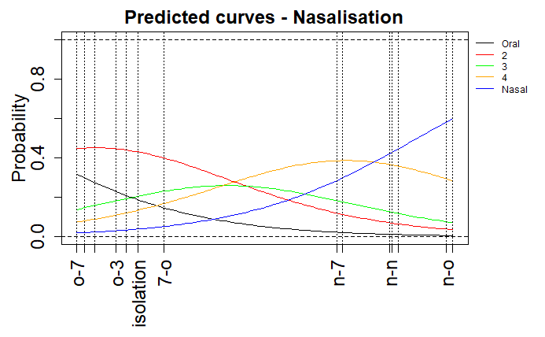

```r
legend(par('usr')[2], par('usr')[4], bty='n', xpd=NA,lty=1, col=c("black", "red", "green", "orange", "blue"),
       legend=c("Oral", "2", "3", "4", "Nasal"),cex=0.75)
```